# 8.3 Lab: Decision Trees

MSBA Team 5

02/15/2020

## 8.3.1 Fitting Classification Trees

```r
rm(list=ls())
# Load libraries function
installIfAbsentAndLoad <- function(neededVector) {
  for(thispackage in neededVector) {
    if( ! require(thispackage, character.only = T) )
    { install.packages(thispackage)}
    library(thispackage, character.only = T)
  }
}
par(mfrow =c(1,1))
needed <- c('tree', "ISLR")
library(ISLR)
# The tree library is used to construct classification and regression trees
library(tree)
```

### Dataset summary and processing

- We first use classification trees to analyze the Carseats data set
- Dataset: Sales of child car seats at 400 different stores
- Target variable: Sales which is unit sales (in thousands) at each location
- ifelse() used to create a new binary variable called ‘High’
- More details on the data set can be found here: https://rdrr.io/cran/ISLR/man/Carseats.html.

```r
attach(Carseats)
head(Carseats)
```

```
##   Sales CompPrice Income Advertising Population Price ShelveLoc Age Education
## 1  9.50       138     73          11        276   120       Bad  42        17
## 2 11.22       111     48          16        260    83      Good  65        10
## 3 10.06       113     35          10        269    80    Medium  59        12
## 4  7.40       117    100           4        466    97    Medium  55        14
## 5  4.15       141     64           3        340   128       Bad  38        13
## 6 10.81       124    113          13        501    72       Bad  78        16
##   Urban  US
## 1   Yes Yes
## 2   Yes Yes
## 3   Yes Yes
## 4   Yes Yes
## 5   Yes  No
## 6    No Yes
```

```r
High = ifelse(Sales <=8 , "No", "Yes")
Carseats = data.frame(Carseats, High)
```

### Fit a model

- Fit a classification tree to predict ‘High’ using all variables but ‘Sales’
- A small deviance indicates a good fit to the training data

```r
# The syntax of the tree() function is quite similar to
# that of the lm() function
tree.carseats = tree(High ~ . -Sales , Carseats)
# The summary() function lists the variables that are used as internal nodes,
# the number of terminal nodes and the training error rate.
summary(tree.carseats)
```

```
##
## Classification tree:
## tree(formula = High ~ . - Sales, data = Carseats)
## Variables actually used in tree construction:
## [1] "ShelveLoc"   "Price"       "Income"      "CompPrice"   "Population"
## [6] "Advertising" "Age"         "US"
## Number of terminal nodes:  27
## Residual mean deviance:  0.4575 = 170.7 / 373
## Misclassification error rate: 0.09 = 36 / 400
```

### Plot a model

- The most important indicator of Sales appears to be shelving location
- Typing in the name of the tree object gives us each branch of the tree
- Left to right: split criterion (e.g. Price <92.5), the number of observations in that branch, the deviance, the overall prediction for the branch (Yes or No), and the fraction of observations in that branch that take on values of Yes and No
- Branches that lead to terminal nodes are indicated using asterisks

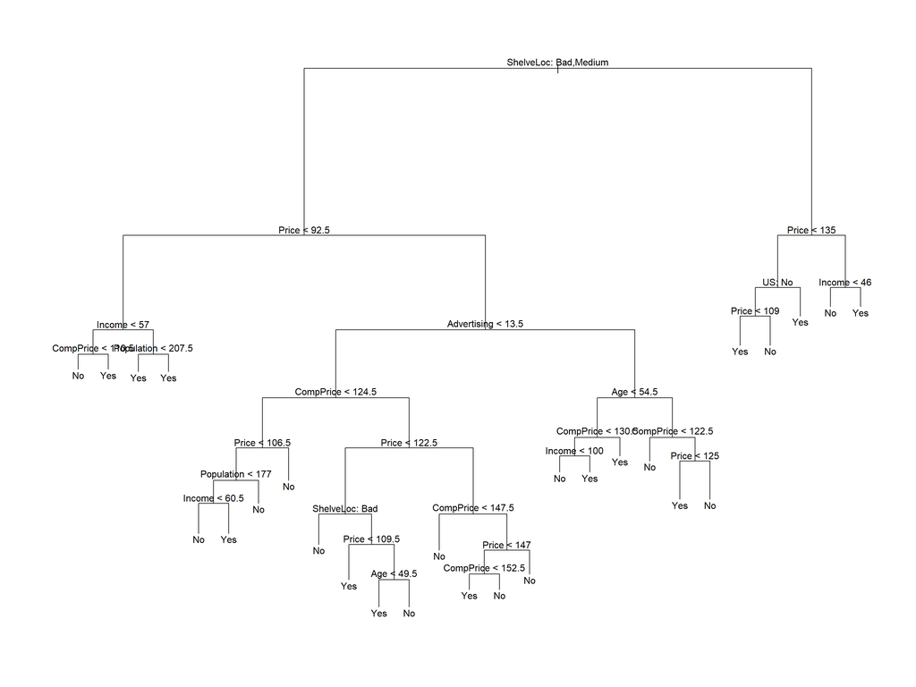

```r
# Use the plot() function to display the tree strucutre
plot(tree.carseats)
# Use the text() function to display the node labels.
# The argument pretty = 0 instructs R to include the category names
# for any qualititaitve predictors, rather than simply displaying
# a letter for each category.
text(tree.carseats,pretty=0)
```

```r
tree.carseats
```

```
## node), split, n, deviance, yval, (yprob)
##       * denotes terminal node
##
##   1) root 400 541.500 No ( 0.59000 0.41000 )
##     2) ShelveLoc: Bad,Medium 315 390.600 No ( 0.68889 0.31111 )
##       4) Price < 92.5 46  56.530 Yes ( 0.30435 0.69565 )
##         8) Income < 57 10  12.220 No ( 0.70000 0.30000 )
##          16) CompPrice < 110.5 5   0.000 No ( 1.00000 0.00000 ) *
##          17) CompPrice > 110.5 5   6.730 Yes ( 0.40000 0.60000 ) *
##         9) Income > 57 36  35.470 Yes ( 0.19444 0.80556 )
##          18) Population < 207.5 16  21.170 Yes ( 0.37500 0.62500 ) *
##          19) Population > 207.5 20   7.941 Yes ( 0.05000 0.95000 ) *
##       5) Price > 92.5 269 299.800 No ( 0.75465 0.24535 )
##        10) Advertising < 13.5 224 213.200 No ( 0.81696 0.18304 )
##          20) CompPrice < 124.5 96  44.890 No ( 0.93750 0.06250 )
##            40) Price < 106.5 38  33.150 No ( 0.84211 0.15789 )
##              80) Population < 177 12  16.300 No ( 0.58333 0.41667 )
##               160) Income < 60.5 6   0.000 No ( 1.00000 0.00000 ) *
##               161) Income > 60.5 6   5.407 Yes ( 0.16667 0.83333 ) *
##              81) Population > 177 26   8.477 No ( 0.96154 0.03846 ) *
##            41) Price > 106.5 58   0.000 No ( 1.00000 0.00000 ) *
##          21) CompPrice > 124.5 128 150.200 No ( 0.72656 0.27344 )
##            42) Price < 122.5 51  70.680 Yes ( 0.49020 0.50980 )
##              84) ShelveLoc: Bad 11   6.702 No ( 0.90909 0.09091 ) *
##              85) ShelveLoc: Medium 40  52.930 Yes ( 0.37500 0.62500 )
##               170) Price < 109.5 16   7.481 Yes ( 0.06250 0.93750 ) *
##               171) Price > 109.5 24  32.600 No ( 0.58333 0.41667 )
##                 342) Age < 49.5 13  16.050 Yes ( 0.30769 0.69231 ) *
##                 343) Age > 49.5 11   6.702 No ( 0.90909 0.09091 ) *
##            43) Price > 122.5 77  55.540 No ( 0.88312 0.11688 )
##              86) CompPrice < 147.5 58  17.400 No ( 0.96552 0.03448 ) *
##              87) CompPrice > 147.5 19  25.010 No ( 0.63158 0.36842 )
##               174) Price < 147 12  16.300 Yes ( 0.41667 0.58333 )
##                 348) CompPrice < 152.5 7   5.742 Yes ( 0.14286 0.85714 ) *
##                 349) CompPrice > 152.5 5   5.004 No ( 0.80000 0.20000 ) *
##               175) Price > 147 7   0.000 No ( 1.00000 0.00000 ) *
##        11) Advertising > 13.5 45  61.830 Yes ( 0.44444 0.55556 )
##          22) Age < 54.5 25  25.020 Yes ( 0.20000 0.80000 )
##            44) CompPrice < 130.5 14  18.250 Yes ( 0.35714 0.64286 )
##              88) Income < 100 9  12.370 No ( 0.55556 0.44444 ) *
##              89) Income > 100 5   0.000 Yes ( 0.00000 1.00000 ) *
##            45) CompPrice > 130.5 11   0.000 Yes ( 0.00000 1.00000 ) *
##          23) Age > 54.5 20  22.490 No ( 0.75000 0.25000 )
##            46) CompPrice < 122.5 10   0.000 No ( 1.00000 0.00000 ) *
##            47) CompPrice > 122.5 10  13.860 No ( 0.50000 0.50000 )
##              94) Price < 125 5   0.000 Yes ( 0.00000 1.00000 ) *
##              95) Price > 125 5   0.000 No ( 1.00000 0.00000 ) *
##     3) ShelveLoc: Good 85  90.330 Yes ( 0.22353 0.77647 )
##       6) Price < 135 68  49.260 Yes ( 0.11765 0.88235 )
##        12) US: No 17  22.070 Yes ( 0.35294 0.64706 )
##          24) Price < 109 8   0.000 Yes ( 0.00000 1.00000 ) *
##          25) Price > 109 9  11.460 No ( 0.66667 0.33333 ) *
##        13) US: Yes 51  16.880 Yes ( 0.03922 0.96078 ) *
##       7) Price > 135 17  22.070 No ( 0.64706 0.35294 )
##        14) Income < 46 6   0.000 No ( 1.00000 0.00000 ) *
##        15) Income > 46 11  15.160 Yes ( 0.45455 0.54545 ) *
```

### Performance Evaluation (Classification)

- Estimate test error using cross validation
- Split the data set and make predictions
- This approach leads to correct predictions for around 77% of the locations in the test data set

```r
nrow(Carseats)
```

```
## [1] 400
```

```r
set.seed(2)
# take 200 rows at random from the Carseats dataset
train = sample(1:nrow(Carseats), 200)
# the non-training rows are now the test set
Carseats.test = Carseats[-train,]
# take the rows that were above that $8K threshold, which we called "High"
High.test = High[-train]
# run our model using tree() package
tree.carseats = tree(High ~ . -Sales, Carseats, subset = train)
# make prediction using test set
# type = "class" instructs R to return the actual class prediction
tree.pred = predict(tree.carseats, Carseats.test, type="class")
table(tree.pred, High.test)
```

```
##          High.test
## tree.pred  No Yes
##       No  104  33
##       Yes  13  50
```

```r
mytable <- table(tree.pred, High.test)
# from book error rate was 71.5%: (86+57)/200. We get 77%:
((mytable["No", "No"] + mytable["Yes","Yes"] )/ sum(mytable) )
```

```
## [1] 0.77
```

### Tree Pruning - Crossvalidation

- QUESTION: Will pruning the tree lead to improved results?
- cv.tree() performs cross-validation to determine the optimal parameter

```r
set.seed(3)
# FUN=prune.misclass is used in order to indicate that we want the
# classification error rate to guide the cross-validation process,
# rather than the default for the cv.tree() function, which is deviance.
cv.carseats = cv.tree(tree.carseats, FUN=prune.misclass)
# The cv.tree() function reports size, the corresponding error rate (dev)
# and the value of the cost-complexity parameter used (k).
names(cv.carseats)
```

```
## [1] "size"   "dev"    "k"      "method"
```

```r
cv.carseats
```

```
## $size
## [1] 21 19 14  9  8  5  3  2  1
##
## $dev
## [1] 74 76 81 81 75 77 78 85 81
##
## $k
## [1] -Inf  0.0  1.0  1.4  2.0  3.0  4.0  9.0 18.0
##
## $method
## [1] "misclass"
##
## attr(,"class")
## [1] "prune"         "tree.sequence"
```

- Plot the error rate as a function of both size and k.

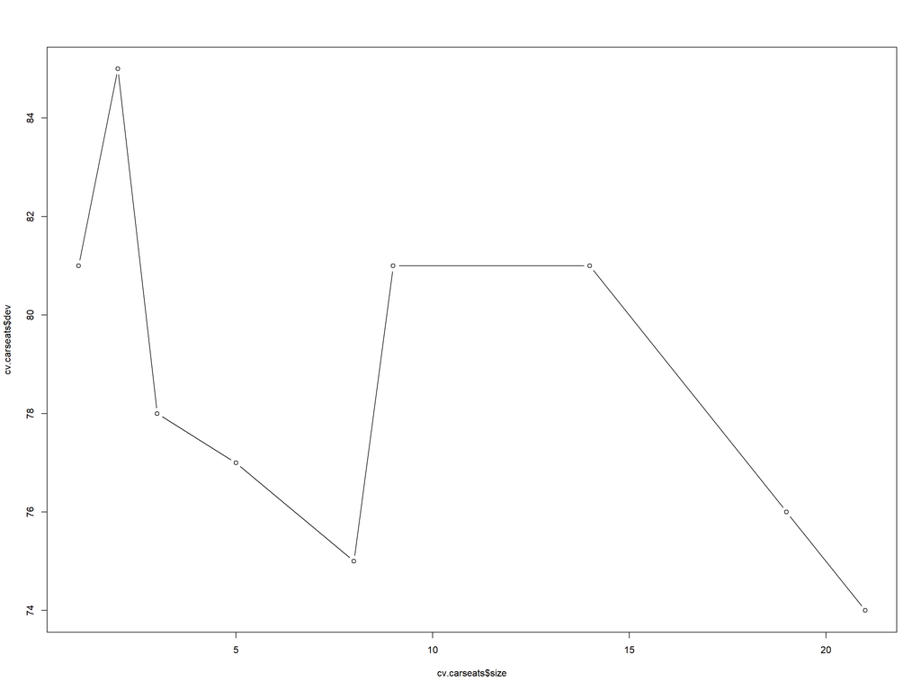

```r
par(mfrow=c(1,1))
# Note that, despite the name, dev corresponds to the cross-validation
# error rate in this instance.
plot(cv.carseats$size, cv.carseats$dev, type="b")
```

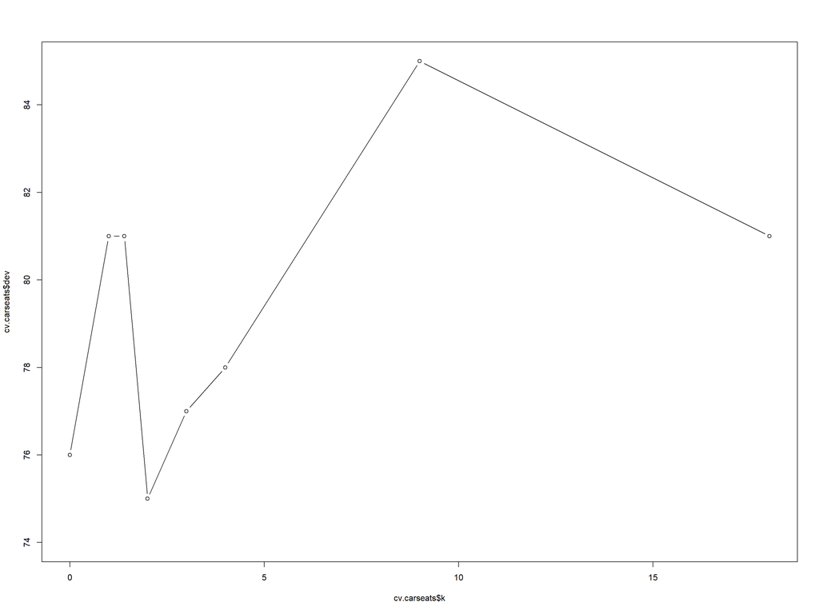

```r
plot(cv.carseats$k ,cv.carseats$dev, type="b")
```

```r
# The tree with 21 terminal nodes results in the lowest cross-validation
# error rate, with 74 cross validation errors.
```

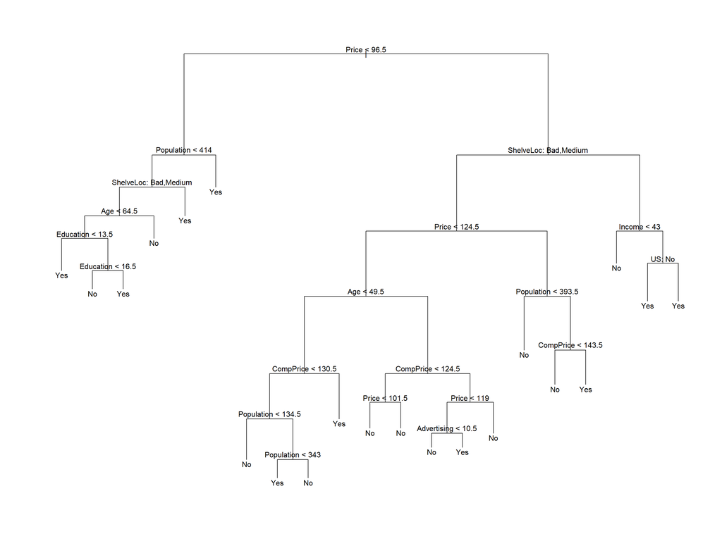

```r
prune.carseats = prune.misclass(tree.carseats, best=21)
plot(prune.carseats)
text(prune.carseats, pretty=0)
```

```r
# How well does this pruned tree perform on the test data set?
tree.pred = predict(prune.carseats, Carseats.test, type="class")
table(tree.pred,High.test)
```

```
##          High.test
## tree.pred  No Yes
##       No  104  32
##       Yes  13  51
```

```r
mytable_pruned <- table(tree.pred,High.test)
((mytable_pruned["No", "No"] + mytable_pruned["Yes","Yes"] )/ sum(mytable_pruned) )
```

```
## [1] 0.775
```

```r
# from book: (94+60)/200
# Now 77.5% of the test observatiosn are correctly classified
```

### Tree Pruning - Manually pick

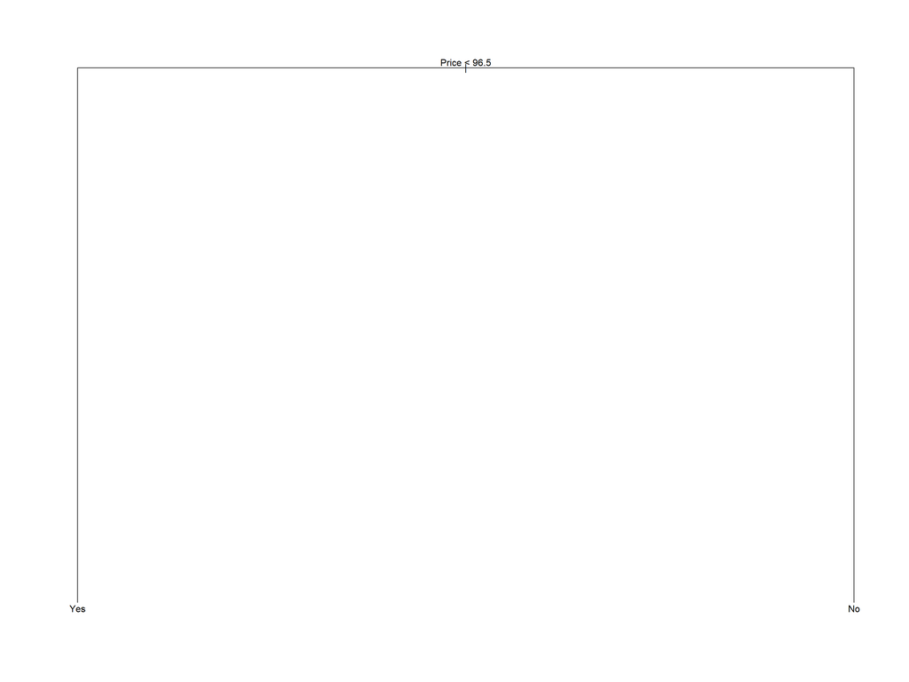

```r
prune.carseats = prune.misclass(tree.carseats, best=2)
plot(prune.carseats)
text(prune.carseats, pretty=0)
```

```r
tree.pred = predict(prune.carseats,Carseats.test,type="class")
table(tree.pred,High.test)
```

```
##          High.test
## tree.pred  No Yes
##       No  104  56
##       Yes  13  27
```

```r
mytable_pruned15 <- table(tree.pred,High.test)
((mytable_pruned15["No", "No"] + mytable_pruned15["Yes","Yes"] )/ sum(mytable_pruned15) )
```

```
## [1] 0.655
```

## 8.3.2 Fitting Regression Trees

### Dataset summary

- Boston dataset comes from the library-Mass
- Target variable is medv which is the median value of homes in $1000’s.
- More details can be found here: https://www.cs.toronto.edu/~delve/data/boston/bostonDetail.html.

```r
rm(list=ls())
library(tree)
library(MASS)
head(Boston)
```

```
##      crim zn indus chas   nox    rm  age    dis rad tax ptratio  black lstat
## 1 0.00632 18  2.31    0 0.538 6.575 65.2 4.0900   1 296    15.3 396.90  4.98
## 2 0.02731  0  7.07    0 0.469 6.421 78.9 4.9671   2 242    17.8 396.90  9.14
## 3 0.02729  0  7.07    0 0.469 7.185 61.1 4.9671   2 242    17.8 392.83  4.03
## 4 0.03237  0  2.18    0 0.458 6.998 45.8 6.0622   3 222    18.7 394.63  2.94
## 5 0.06905  0  2.18    0 0.458 7.147 54.2 6.0622   3 222    18.7 396.90  5.33
## 6 0.02985  0  2.18    0 0.458 6.430 58.7 6.0622   3 222    18.7 394.12  5.21
##   medv
## 1 24.0
## 2 21.6
## 3 34.7
## 4 33.4
## 5 36.2
## 6 28.7
```

```r
set.seed(1)
# Created a training set, and fit the tree to the training data.
train = sample(1:nrow(Boston), nrow(Boston)/2)
```

### Fit a model

- tree() is used again for fitting a tree model
- In the context of a regression tree, the deviance is the sum of squared errors for the tree

```r
tree.boston = tree(medv~.,Boston,subset=train)
summary(tree.boston)
```

```
##
## Regression tree:
## tree(formula = medv ~ ., data = Boston, subset = train)
## Variables actually used in tree construction:
## [1] "rm"    "lstat" "crim"  "age"
## Number of terminal nodes:  7
## Residual mean deviance:  10.38 = 2555 / 246
## Distribution of residuals:
##     Min.  1st Qu.   Median     Mean  3rd Qu.     Max.
## -10.1800  -1.7770  -0.1775   0.0000   1.9230  16.5800
```

### Plot the tree

- The variable rm measures average number of rooms per dwelling
- Higher values of rm correspond to more expensive houses
- The tree precits median house price of $45,380 for larger homes in the suburbs with more rooms (rm >=7.553)

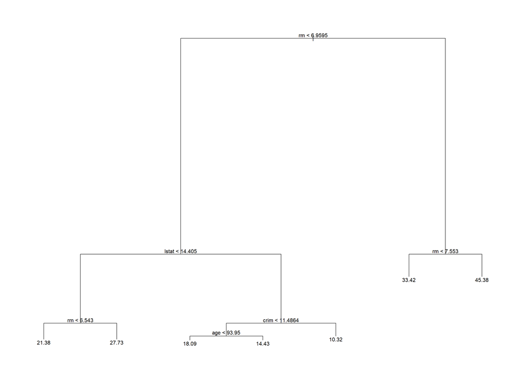

```r
plot(tree.boston)
text(tree.boston,pretty=0)
```

### Tree pruning

- cv.tree() will be used to find the best parameter
- plot() shows us the size of tree that gives the lowest sum of sqaured errors
- The unpruned tree gives us the lowest error

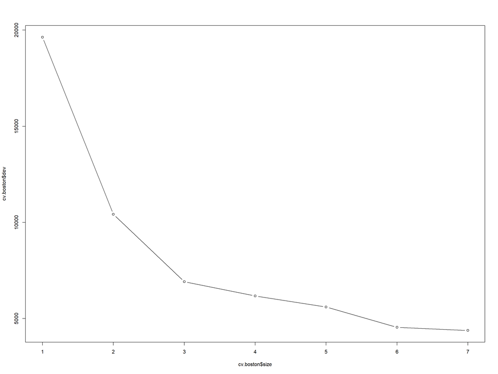

```r
cv.boston=cv.tree(tree.boston)
plot(cv.boston$size, cv.boston$dev, type='b')
```

- We can still prune if we want to by using prune.tree() function

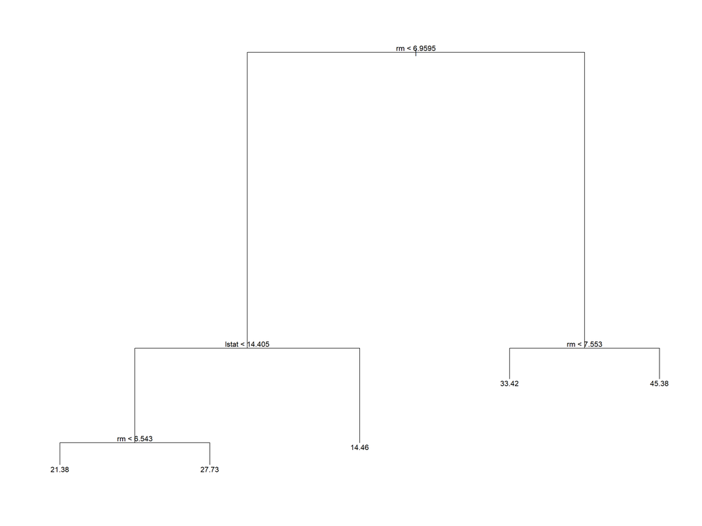

```r
prune.boston=prune.tree(tree.boston, best=5)
plot(prune.boston)
text(prune.boston, pretty = 0)
```

### Performance Evaluation (Regression)

- In keeping with cross-validation results, we use the unpruned tree to make predictions on the test set

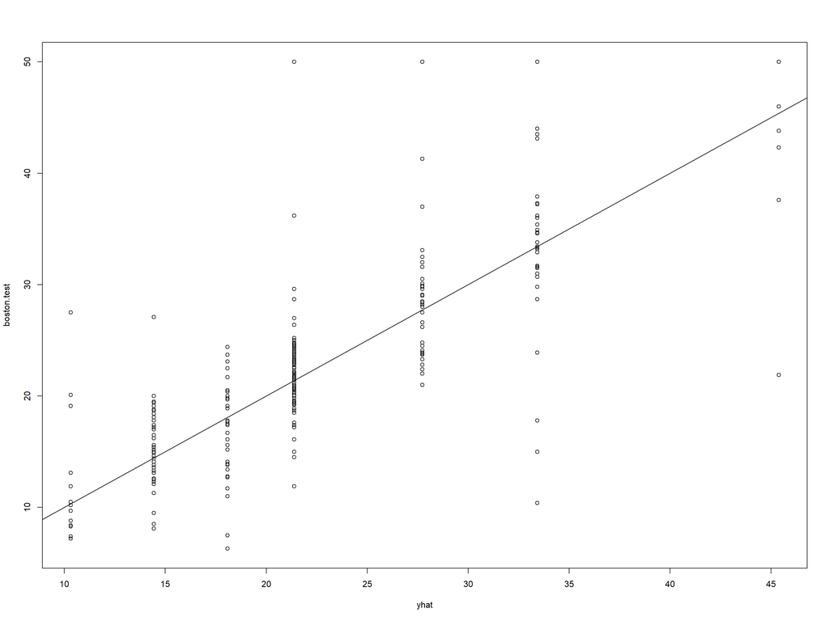

```r
# predictions
yhat=predict(tree.boston, newdata=Boston[-train,])
# actual prices
boston.test=Boston[-train,"medv"]

plot(yhat,boston.test)
abline(0,1)
```

- The Test MSE associated with the regression tree is 35.28688
- The square root of the MSE is around 5.9402, indicating that this model leads to test predictions that are within around $5,940 of the true median home value for the suburb

```r
mean((yhat-boston.test)^2)
```

```
## [1] 35.28688
```

```r
sqrt(mean((yhat-boston.test)^2))
```

```
## [1] 5.940276
```

## Summary

- tree() for building a model
- cv.tree() for finding the best parameter
- prune.misclass() or prune.tree() for tree pruning (be careful with method)